# 2023 Pre-assessment workshop for black rockfish in waters off Washington state

Jason M. Cope, Northwest Fisheries Science Center

Tien-Shui Tsou, Washington Department of Fish and Wildlife

Lisa K. Hillier, Washington Department of Fish and Wildlife

Kristen E. Hinton, Washington Department of Fish and Wildlife

Corey B. Niles, Washington Department of Fish and Wildlife

2023-01-31

*Disclaimer: All data summaries and exploration presented here are preliminary and may not be indicative of the final data that will be incorporated in the 2023 assessment models*

# Overview

Description of data and model specification being considered for use in the 2023 assessments for black rockfish off Washington.

# Summary of the 2015 Assessment

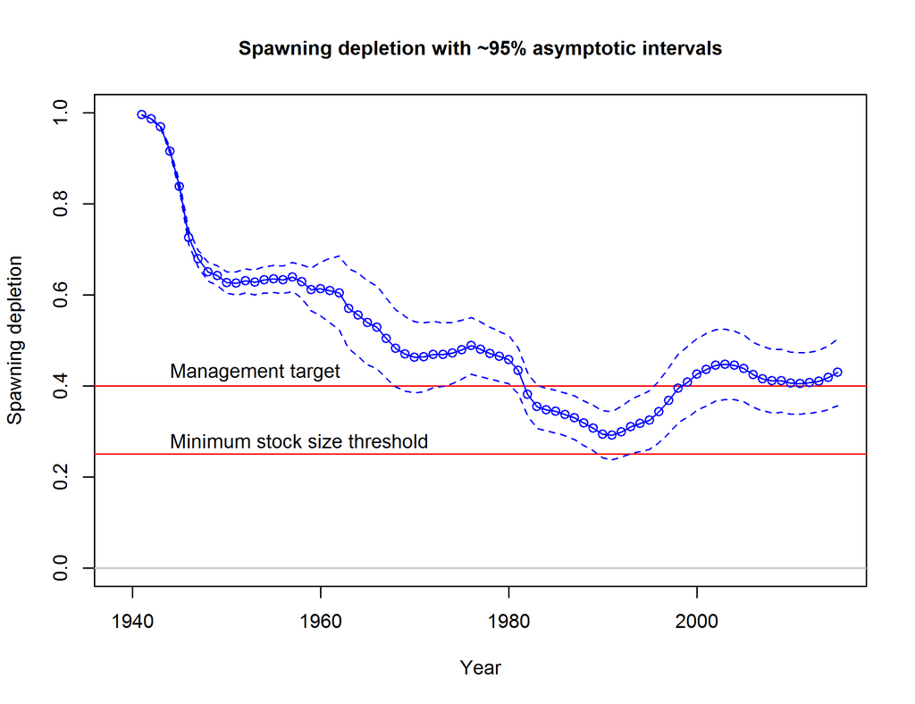

Estimates of relative stock size (current spawning output/unfished spawning output) for black rockfish in waters off of Washington from the 2015 assessment. Broken lines are 95% confidence intervals.

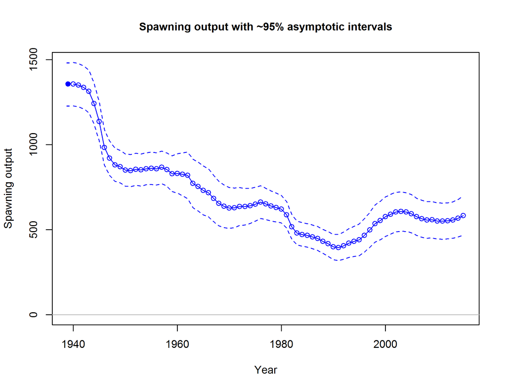

Estimates of spawning output (millions of eggs) for black rockfish in waters off of Washington from the 2015 assessment. Broken lines are 95% confidence intervals.

# Bridging the assessment model from Stock Synthesis 3.24 to 3.30

Since several years have passed from the last assessment model, the Stock Synthesis (SS) modelling framework has undergone many changes. While the specific changes in the model can be found in the model [change log](https://github.com/nmfs-stock-synthesis/stock-synthesis/blob/v3.30.19/Change_log_for_SS_3.30.xlsx?raw=true), here we simply update the model from the older 3.24V version to the newer 3.30.20 version. The point here is to present any differences in the model outputs when using the same information. This was first done by migrating the data and parameter specifications from the former files to the newer files. This migration was assisted using the [SS-DL tool](https://github.com/shcaba/SS-DL-tool). Once the old data was transferred to the SS 3.30.20 file, two versions of the model were ran.

1. Fixing all parameter values to the values found in the 2015 model.
2. Allowing the same parameters estimation specification as in the 2015 model.

Results are similar between models when all parameters are fixed from the 2015 model in the updated SS files, although there are scale differences and small relative stock status differences when the new SS version is allowed to estimate the same parameters as estimated in the 2015 version. These model comparisons are adequate to move ahead using the newest version of SS 3.30.20 without expecting large differences in reference models being due to versions of SS.

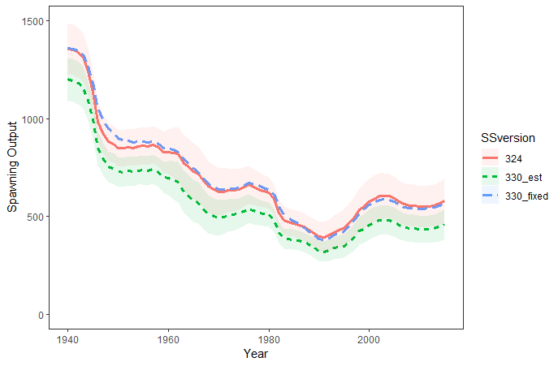

Comparison of spawning output for black rockfish in waters off of Washington between Stock Synthesis versions 3.24 and 3.30. Uncertainty envelops are 95% confidence intervals.

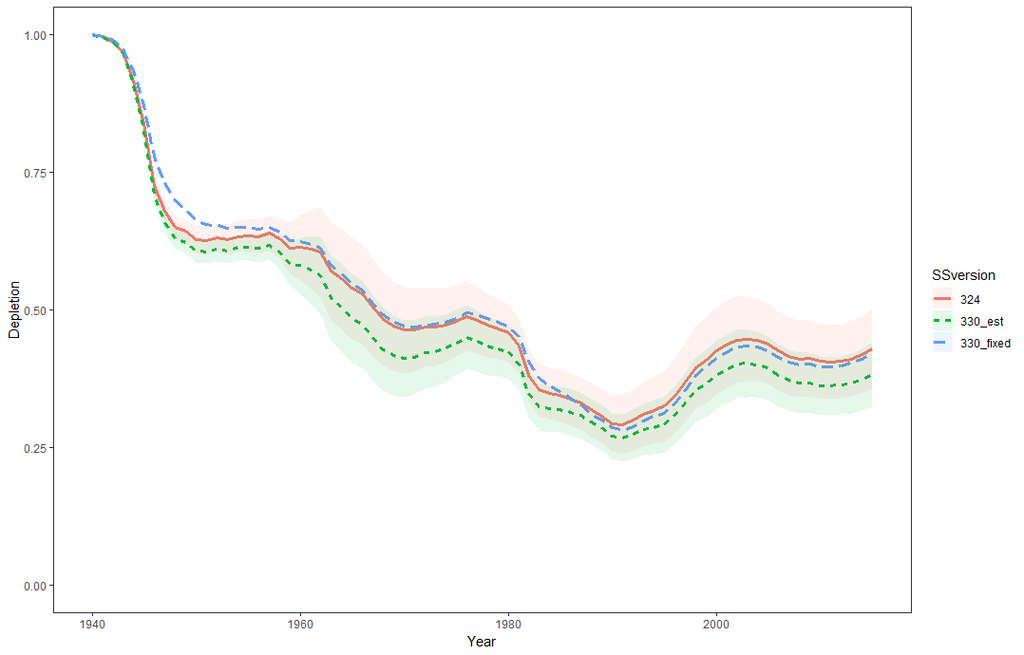

## Unresolved Questions and Issues from the 2015 Assessments

1. Investigation of the lack of older (> age 10) females in data. This affects the definition of natural mortality and selectivity values for females.
2. Improved historical catch reconstructions. The trawl fishery catches in particular need attention.
3. Identifying stanzas or periods of uncertainty in the historical catch series will aid in the exploration of catch uncertainty in future assessment sensitivity runs.
4. Evaluate a nearshore survey or other relevant surveys.
5. Stock structure for black rockfish.

# Stock Structure

The stock structure of black rockfish continues to be based on state-specific boundaries. Stock definitions are based on a variety of factors that include genetics, biology, ecology, habitat availability and fishing mortality history. Black rockfish range from southern California up to Alaska. Their ecology as a nearshore (i.e., commonly an area of restricted gene flow) rockfish with semi-pelagic behavior (e.g., can demonstrate rare, but substantial adult movements) under strong and differential fishing pressure by state provides an interesting assortment of considerations. A recent genetics study done by Hess et al. ([2022](https://github.com/shcaba/Sebastes_melanops_WA/blob/main/References/Hess%20et%20al.%20-%202022%20-%20Comparative%20phylogeography%20of%20a%20bathymetrically%20se.pdf)) found that Alaskan and west coast populations showed significant genetic difference. The population from Washington to California showed a variety of interesting genetic signatures, with decreased genetic diversity north of Cape Mendocino and North of the Columbia River, but increasing in waters off Oregon. There were also pockets of isolation by distance and odd signatures off Brookings, Oregon. These variable genetic signatures combined with the lack of consistent black rockfish habitat in southern Washington, and the different exploitation histories in each of the states made state-level designations to support management decisions the most logical. This does not suggest there is no exchange of individuals among California, Oregon and Washington, but instead acknowledges that the exchange is likely low enough not to homogenize the populations, and that different population trends can be expected in each state. This was supported in the results of the last assessment, where important differences in stock status were observed.

# Fleet Structure

Currently, the following fleet structure is being considered for modeling commercial and recreational fisheries in both area models:

1. Commercial trawl (mostly a historical fishery)
2. Commercial hook and line (mostly a jig fishery in the 1980s)
3. Recreational (sport) fishery

Defining fleets is largely based on whether a fishing approach differs in the selectivity (i.e., the capture of fish by length and/or age). Selectivity translates into how the removals are taken via length and/or age out of the population. The above three fishery types are distinguished by different fishing activities that result in different selectivities. The fleets are the same as those defined in the 2015 assessment.

# Removal Data

## Commercial Landings & Discards

Black rockfish are not considered a major commercial species in Washington, but historical reconstructions have shown prominent trawl and notable jig catches in the past that have subsequently waned over the last 40 years. Historical catch reconstructions were done for the 2015 assessment (see that assessment for the details), and are heavily based on fish ticket reporting and applying highly variable catch compositions to years that do not have measured compositions, but rather just report total or “unknown” rockfish catches, though there was some direct reporting of a black rockfish category that was a mix of other rockfishes. In addition, there is a major interaction in the estimates of trawl-caught black rockfish between Oregon and Washington in reporting area 3A due to the fact that fishers from Astoria fished off Washington and landed those fish in Oregon. This has resulted in some of the largest black rockfish catches ever seen. We are re-evaluating these assumptions along with the Oregon catch reconstruction.

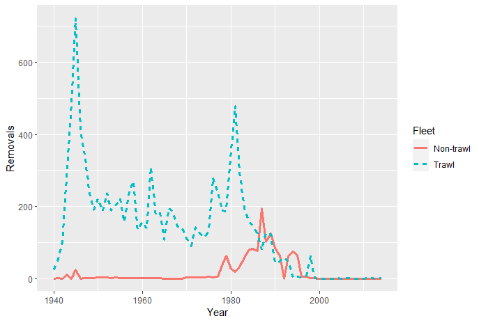

Total removals (landings plus dead discards) for commercial-caught black rockfish used in the 2015 assessment.

### Additional Items for Discussion

- See the discussion on allocating 3A trawl
- Bottom trawl catch history and the translation of state area codes to PacFIN Catch Area Code 3A (45 46’ N. lat TO 47 20’ N. lat.; Cape Falcon to Cape Elizabeth) and how catch should be divided between the two assessment areas.
- PacFIN species composition of Washington landings, 1981-1999, for trawl and non-trawl (primarily jig) gears.
- Evaluation of historical species composition data (i.e. pre-1981).

## Recreational Landings & Discards

The sport caught (recreational) fishery landings underwent a major reconstruction in the 2015 assessment. This reconstruction is largely maintained in the new assessment. The only update is that the predictive dead discard to landings ratio was updated by including the years 2015-2022 to the already used 2002-2014 values. The addition of 8 years to the 13 years did not perceptibly change the relationship (i.e., was consistent with the previous relationship) used to estimate discards back in time. The full time series of recreational removals therefore is very similar to what was used before, with the addition of new removal estimates in the years since the last assessment.

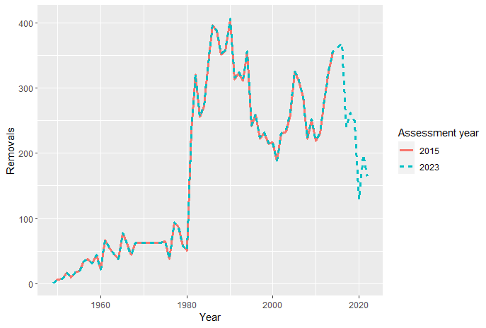

Total removals (landings plus dead discards) for sport-caught black rockfish used in the 2015 assessment versus those proposed in the 2023 assessment.

### Additional Items for Discussion

*Nothing additional for the recreational fishery

# Indices of Abundance

The 2015 assessment included fishery-independent abundance indices based on tag-release CPUE data from the Black Rockfish tagging program from 1986-2014, and a fishery-dependent index based on recreational dockside fisheries data from 1981-2014. This assessment will again incorporate both fishery-independent and fishery-dependent abundance indices.

## Fishery-Dependent

- Recreational Dockside Index (1981-2022): Recreational dockside fisheries data were used in the previous assessment for 1981-2014 (N=61,574). Data are available for this series from 1981 through 2022. In the 2015 assessment this data series was modeled with a delta-GLM approach using catch per angler-day by vessel, with recreational dockside data samples filtered using the Stevens-MacCall (2004) method. The updated index will fix an error in the calculation of the effort.

## Additional Items for Discussion

# Composition Data

Sample sizes are consistent with the history of the fisheries, with commercial catches higher pre-2000s and the sport fishery better sampled post-2000s.

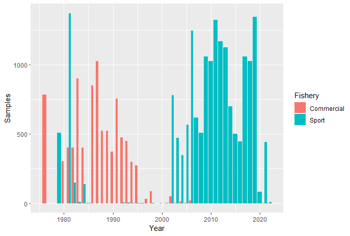

## Commercial length compositions

The commercial data is best sampled in the 1980s. This mainly historical data is likely going to be the same as was used in the 2015 assessment.

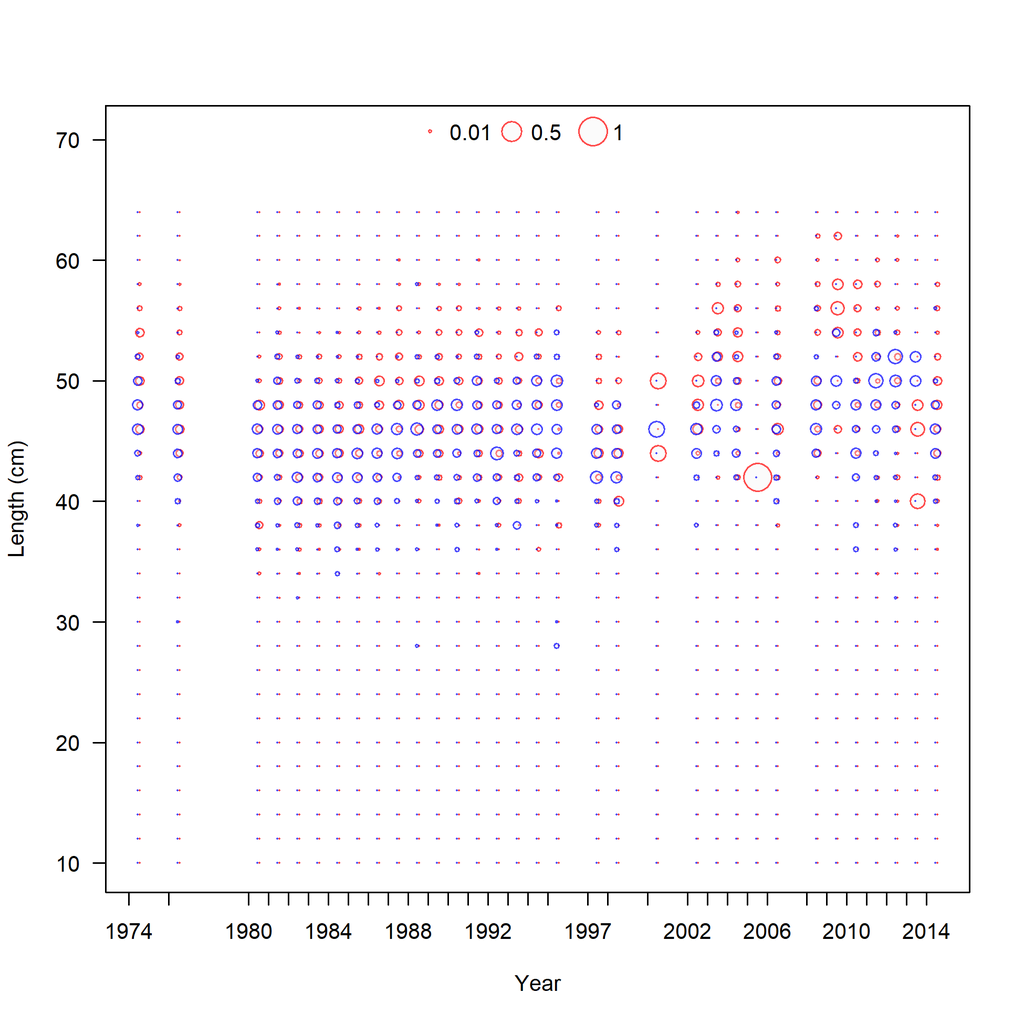

Length composition data by sex and year for black rockfish based on fish sampled in the Washington trawl fishery.

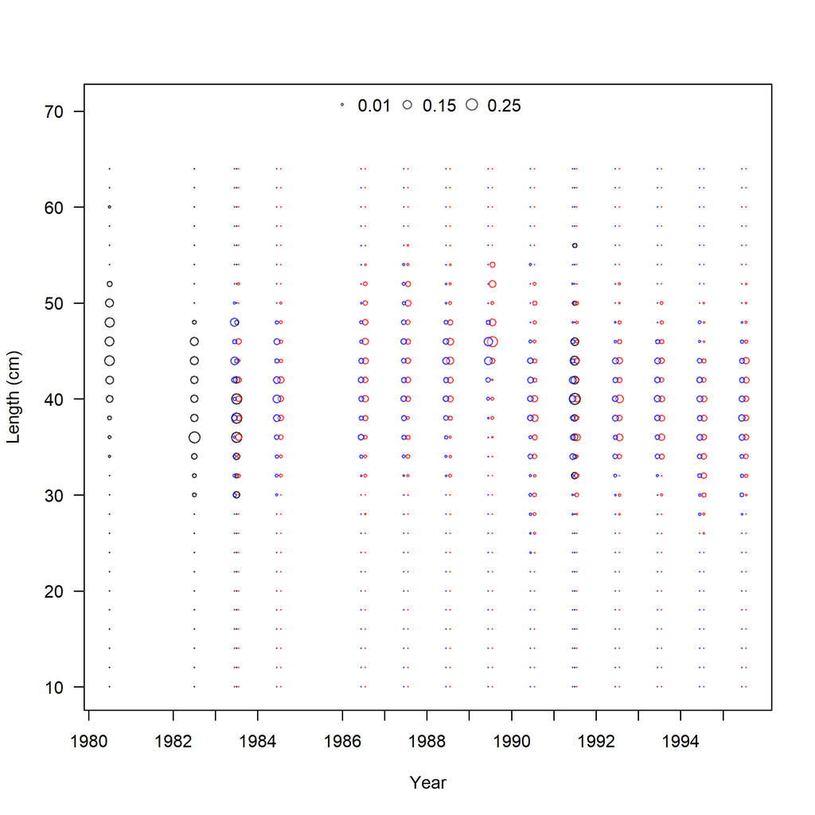

Length composition data by sex and year for black rockfish based on fish sampled in the Washington non-trawl fishery.

## Recreational length compositions

The recreational fishery provides a long time series of length composition by sex. These data are useful for determining fishery selectivity, identifying possible recruitment events and indicating the overall stock status of black rockfish in Washington. Overall, females are slightly larger than males.

There is also the important issue of defining the effective sample size, which creates the relative weights among years and fleets.

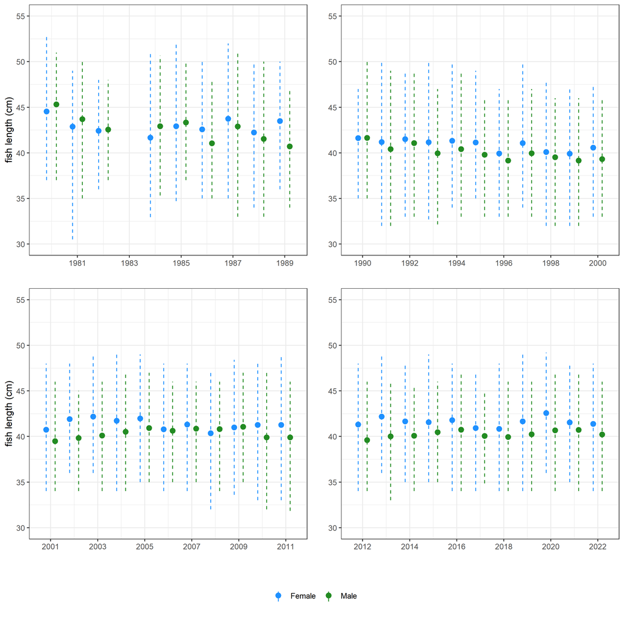

Female and Male length composition data by year for black rockfish based on fish sampled in the Washington sport fishery.

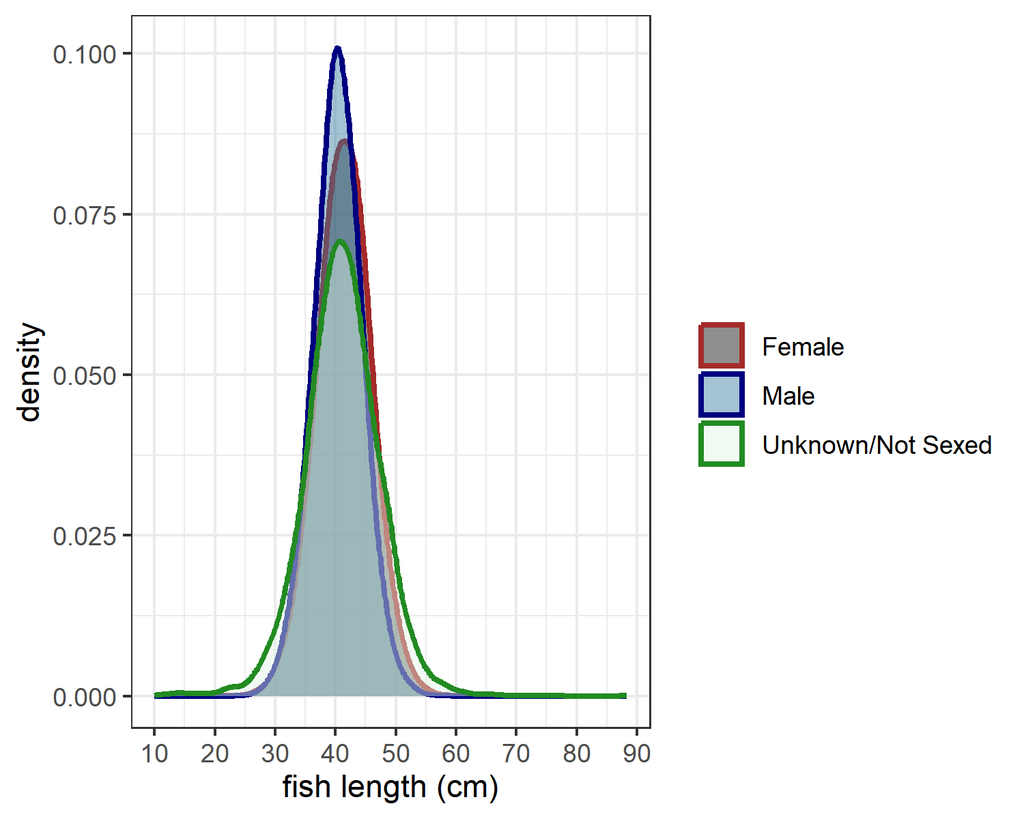

Aggregate length composition data by sex for black rockfish based on fish sampled in the Washington sport fishery.

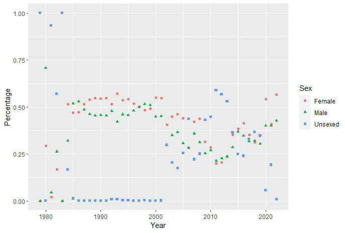

Percentage of sexed and unsexed samples in the length composition data for black rockfish based on fish sampled in the Washington sport fishery.

## Survey length compositions

Three of the surveys are related to the sport fishery, but two of them (the tag and nearshore surveys) have their own lengths to use to estimate selectivity. The dockside survey is directly sampled from the sport fishery and therefore mirrors the sport fishery selectivity. The nearshore SCUBA survey will either be a recruitment survey or assume a fixed selectivity above a certain length, which is to be determined.

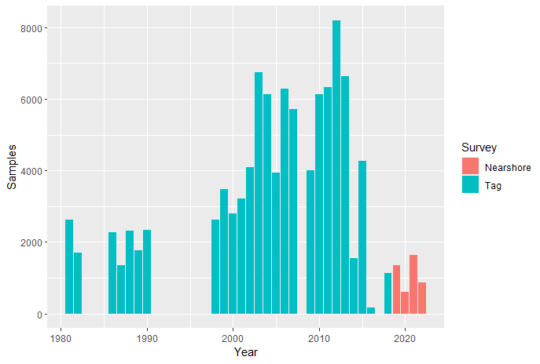

Numbers of black rockfish lengths sampled for the tag and nearshore surveys.

# Biology

## Maturity and Fecundity

Maturity will borrow values from the Oregon maturity analysis.

Fecundity-at-length is based on Dick et al. (2017) and is similar to what was assumed in the last assessment.

## Length-Weight

The length-weight are given in the figure below. Males: W = 0.0000303L^2.843 Females: W = 0.00002881L^2.857

These values are updated with additional samples, yet still similar to those used in the 2015 assessment.

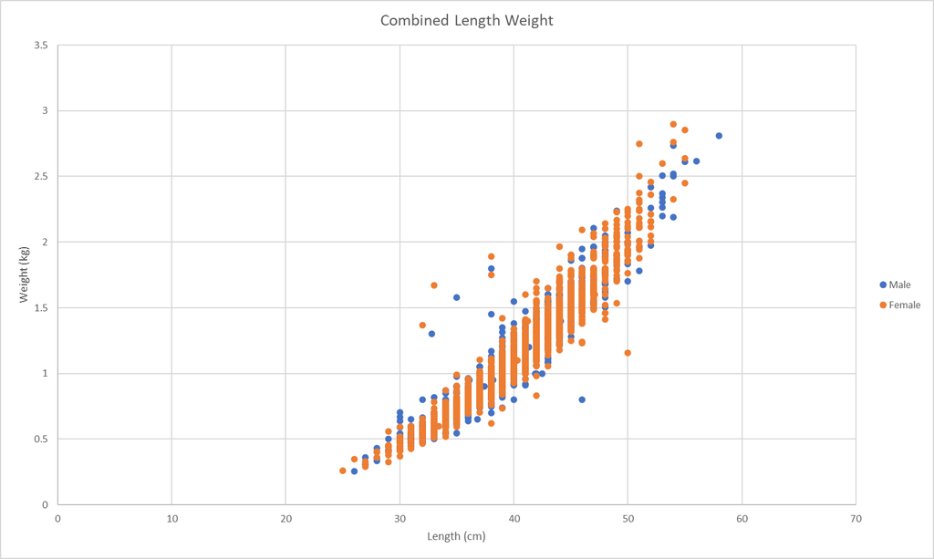

Length-weight relationship for black rockfish based on fish sampled in Washington ports.

## Age and Growth

Ages are expected to be completed in the next month and will be added to the previous ages in the 2015 assessment. These data will be used to estimate growth outside and inside (as conditional age at length data) the model with the hope we can use internally estimated growth estimates.

The current available samples of age and lengths by sex are shown below. The female to male sex ratio after age 25 is apparent.

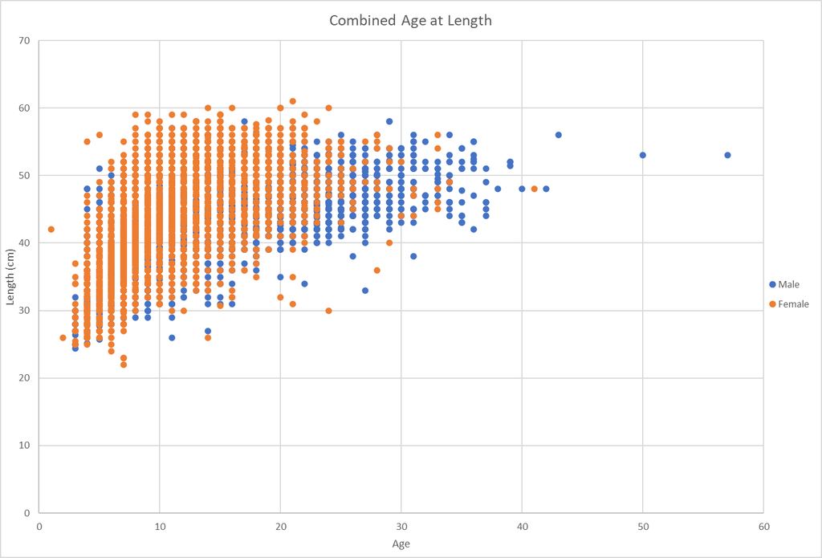

Female and Male age and length data for black rockfish based on fish sampled in Washington ports.

## Natural Mortality

Natural mortality is not directly measured, but has been estimated in past assessments. We will again attempt to estimate natural mortality for both males and females separately. Females demonstrate a lower frequency of occurrence than expected once they get past age 20-25. This issue is seen from California to Alaska, and has been extensively explored in the “kill ’em or hide ’em” hypotheses. These suggest either females are dying off quicker once they reach maturity (i.e., use an elevated natural mortality to kill them in the model) or have age-specific fishing avoidance behavior causing age-based dome-shaped gear selectivity (i.e., hide them from the fishery and create cryptic biomass). These hypotheses were extensively explored in the last assessment. As in the last assessment, we will likely estimate a constant natural mortality for females that is expected to be higher than for males. We will use the [Natural Mortality Tool](https://connect.fisheries.noaa.gov/natural-mortality-tool/) to develop a prior for black rockfish.